### Luca Fregona

# ANDAMENTO DI UN AIRBNB:

# **VENEZIA**

#### Progetto Data Science

## **MOTIVAZIONI:**

Il mercato degli affitti brevi rappresenta un settore di grande interesse. Questo progetto mira a esplorare la situazione attuale degli airBnB nel contesto unico della città di Venezia, combinando analisi dati e strategie mirate per identificare le migliori caratteristiche degli annunci.

## **OBBIETTIVO POSTO**

1. Analizzare i dati più rilevanti relativi agli AirBnB a Venezia al fine di individuarne le migliori caratteristiche.

## **DESCRIZIONE DEL DATAFRAME**

Il download del dataframe è disponibile su Inside AirBnB oppure al seguente link: [Download](https://data.insideairbnb.com/italy/veneto/venice/2024-12-07/data/listings.csv.gz)

#### Per preparare il dataframe alla visualizzazione ho:

- Rimosso le colonne poco rilevanti per l'analisi come "Host_name" e "Minimum_Nights".
- Escluso le proprietà sulla terraferma di Venezia.
- Droppato le righe con valori NaN nelle categorie più rilevanti (es. 'Price').
- Riempito le righe con valori NaN con informazioni opportune nelle altre colonne.
- Sistemato alcuni Dtype.

```
<class 'pandas.core.frame.DataFrame'>
RangeIndex: 5538 entries, 0 to 5537
Data columns (total 21 columns):
 #   Column                        Non-Null Count  Dtype
---  ------                        --------------  -----
 0   id                            5538 non-null   int64
 1   name                          5538 non-null   object
 2   description                   5538 non-null   object
 3   host_name                     5538 non-null   object
 4   host_since                    5538 non-null   datetime64[ns]
 5   host_is_superhost             5538 non-null   int64
 6   neighbourhood_cleansed        5538 non-null   object
 7   neighbourhood_group_cleansed  5538 non-null   object
 8   latitude                      5538 non-null   float64
 9   longitude                     5538 non-null   float64
 10  room_type                     5538 non-null   object
 11  accommodates                  5538 non-null   int64
 12  bathrooms                     5538 non-null   float64
 13  bedrooms                      5538 non-null   int64
 14  amenities                     5538 non-null   object
 15  price                         5538 non-null   float64
 16  number_of_reviews             5538 non-null   int64
 17  review_scores_rating          5538 non-null   float64
 18  reviews_per_month             5538 non-null   float64
 19  review_scores_location        5538 non-null   float64
 20  room_type_encoded             5538 non-null   int64
dtypes: datetime64[ns](1), float64(7), int64(6), object(7)
memory usage: 908.7+ KB
```

## Analizzare i dati più rilevanti relativi agli AirBnB a Venezia al fine di individuarne le migliori caratteristiche.

### A: Analisi del prezzo in base alla struttura degli AirBnB

[figure not shown]

```
La percentuale di 'Entire home/apt' è 86.67%
```

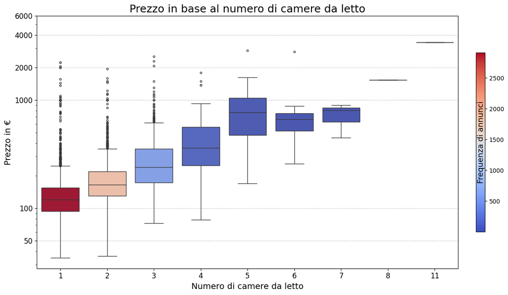

```
Correlazione tra 'bedrooms' e 'price': 0.41
```

```
La percentuale di appartamenti con meno di 3 camere è 87.23%
```

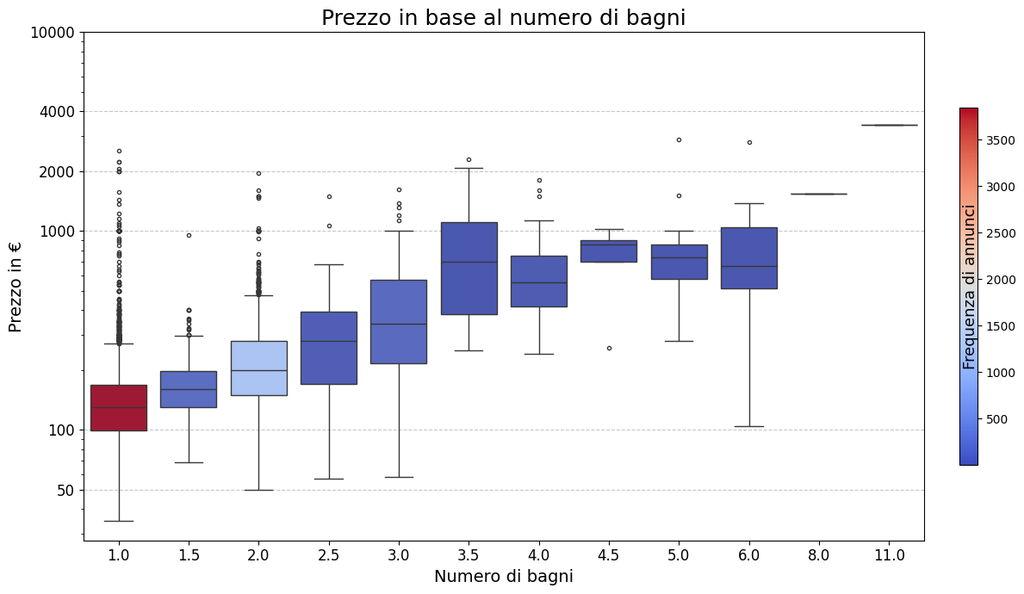

```
Correlazione tra 'bathrooms' e 'price': 0.47
```

```
La percentuale di appartamenti con meno di 2.5 bagni è 94.28%
```

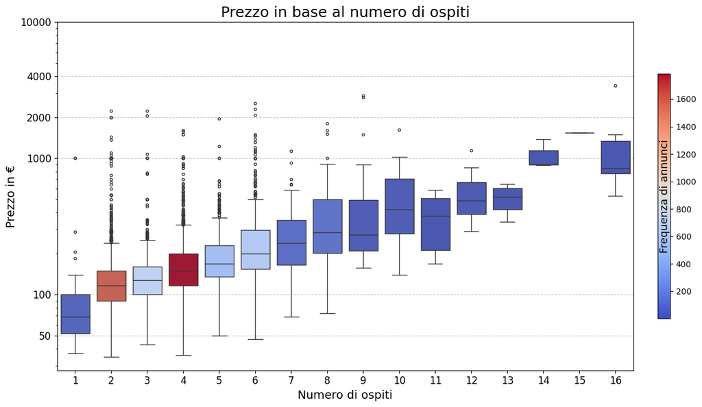

```
Correlazione tra 'accommodates' e 'price': 0.36
```

```
La percentuale di appartamenti con meno di 5 ospiti è 74.25%
```

### B: Analisi del prezzo in base alla distribuzione geografica degli AirBnB

### Heatmap della distribuzione dei prezzi sulla cartina di Venezia

Make this Notebook Trusted to load map: File -> Trust Notebook

[interactive chart not shown]

```
Quartieri con prezzi medi bassi e ottime recensioni medie:
╒═════════════╤══════════╤═══════════════╤═════════════════════════╤═══════════╕
│ Quartiere   │   Prezzo │   Valutazione │   Valutazione Posizione │   Annunci │
╞═════════════╪══════════╪═══════════════╪═════════════════════════╪═══════════╡
│ Burano      │  157.48  │       4.9252  │                 4.9568  │        25 │
├─────────────┼──────────┼───────────────┼─────────────────────────┼───────────┤
│ Murano      │  144.351 │       4.87405 │                 4.89095 │        74 │
╘═════════════╧══════════╧═══════════════╧═════════════════════════╧═══════════╛
```

### C: Analisi del prezzo in base alle recensioni degli AirBnB

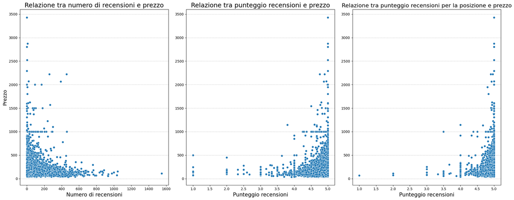

```
Correlazione Pearson tra Numero di recensioni e Prezzo: -0.1241
```

```
Correlazione Pearson tra Valutazione delle recensioni e Prezzo: 0.1044
```

```
Correlazione Pearson tra Valutazione delle recensioni per la posizione e Prezzo: 0.0905
```

### C: Analisi del prezzo in base ai servizi offerti dagli AirBnB

#### Migliori e peggiori servizi per correlazione con il prezzo

```
╒═════════════════════╤══════════╤═══════════════════════════╤════════════╕
│ Migliori            │     Corr │ Peggiori                  │       Corr │
╞═════════════════════╪══════════╪═══════════════════════════╪════════════╡
│ Dishwasher          │ 0.167953 │ Portable air conditioning │ -0.0309595 │
├─────────────────────┼──────────┼───────────────────────────┼────────────┤
│ Dryer               │ 0.143393 │ Single level home         │ -0.0311487 │
├─────────────────────┼──────────┼───────────────────────────┼────────────┤
│ Canal view          │ 0.118391 │ Hot water                 │ -0.0478468 │
├─────────────────────┼──────────┼───────────────────────────┼────────────┤
│ Bathtub             │ 0.112999 │ Pets allowed              │ -0.0485578 │
├─────────────────────┼──────────┼───────────────────────────┼────────────┤
│ Patio or balcony    │ 0.107254 │ Mosquito net              │ -0.0545593 │
├─────────────────────┼──────────┼───────────────────────────┼────────────┤
│ Dedicated workspace │ 0.106627 │ Self check-in             │ -0.0605622 │
├─────────────────────┼──────────┼───────────────────────────┼────────────┤
│ City skyline view   │ 0.105931 │ Lockbox                   │ -0.0718978 │
├─────────────────────┼──────────┼───────────────────────────┼────────────┤
│ Outdoor furniture   │ 0.101816 │ Lock on bedroom door      │ -0.0879328 │
╘═════════════════════╧══════════╧═══════════════════════════╧════════════╛
```

## Conclusioni sull'analisi di Airbnb a Venezia

*La maggior parte degli alloggi sono intere case (86,7%) e hanno meno di tre camere e 2,5 bagni. Il prezzo dipende da dimensioni e posizione: San Marco è il quartiere più costoso, mentre Murano e Burano offrono soluzioni economiche con ottime recensioni.*